# notes

OMARJEE Abdoullatif

2024-05-23

# TP01 OMARJEE Abdoullatif

l’objectif de ce TP est de se familiariser avec les outils de régression linéaire sur R.  
Ce compte rendu a été réalisé de sorte à pouvoir retourner sur les scripts R et de les rééxécuter à souhait , au besoin.  
De ce fait, la démultiplication des scripts R ont été volontairement choisies au profit de la lisibilité du markdown, de sorte à ce que le lecteur puisse se réapproprier le projet sans s’y perdre.

## Exercice 1

[figure not shown]

### question 1 :

on remarque qu’il y a plusieurs valeurs anormales : par exemple, le bmi ( IMC ) ne peut pas être de 0 comme vu sur données .  
on observe les mêmes problèmes concernant la variable glucose , diastolic , insulin , triceps.  
Pour aller plus loin, on se munit d’un dataframe pimanull dans lequel on a stocké les observations de pima qui posent problème.  
On a ensuite affiché le nombre d’observations de pima et de pimanull.On remarque que les données qui posent problème sont non négligeables au vu des données, et représentent presque la moitié.  
Notre choix a donc été de séparer les données problématiques pour ne conserver que les données cohérentes.  
On a donc corrigé les données, en stockant les résultats dans pima1

### question 2 :

Notre choix a donc été de séparer les données problématiques pour ne conserver que les données cohérentes.  
On a donc corrigé les données, en stockant les résultats dans pima1  
on se sépare des données problématiques et on les stocke dans l’environnement sous le nom de pima1 , on a utilisé la commande which en conséquence.  
en ressortant le résumé du dataframe, on remarque que les variables sont beaucoup plus cohérentes.

### question 3 :

Dans le script dédié à la pression sanguine, on utilise la fonction hist pour afficher les données liées à la pression sanguine diastolique , appelée diastolic dans le dataframe pima1 que nous utiliserons pour toute la suite de l’étude.  
On a ensuite utilisé la fonction lines sur l’estimateur à noyau de la densité que, lequel on s’en munit grâce à la commande density.

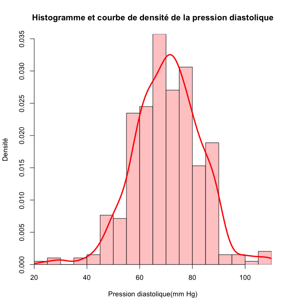

### question 4 :

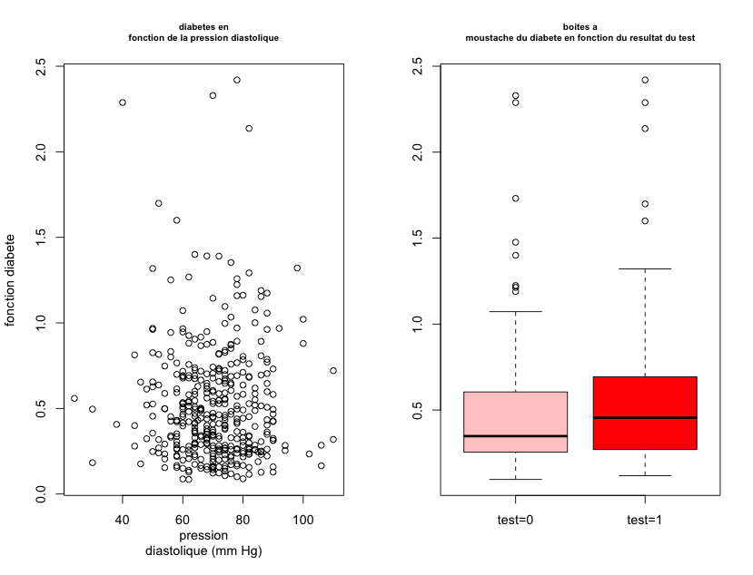

### question 5 :

Dans le script dédié à matrice , on affiche la matrice deux à deux pairs des données de Pima pima1 ( on a paramétré un jeu de couleurs à l’aide de la librairie graphics et de la fonction colors(), qui à chaque variable associe une couleur).  
On n’est en mesure de remarquer des informations particulières tant cette matrice deux à deux ne nous offre qu’une vue globale des données.

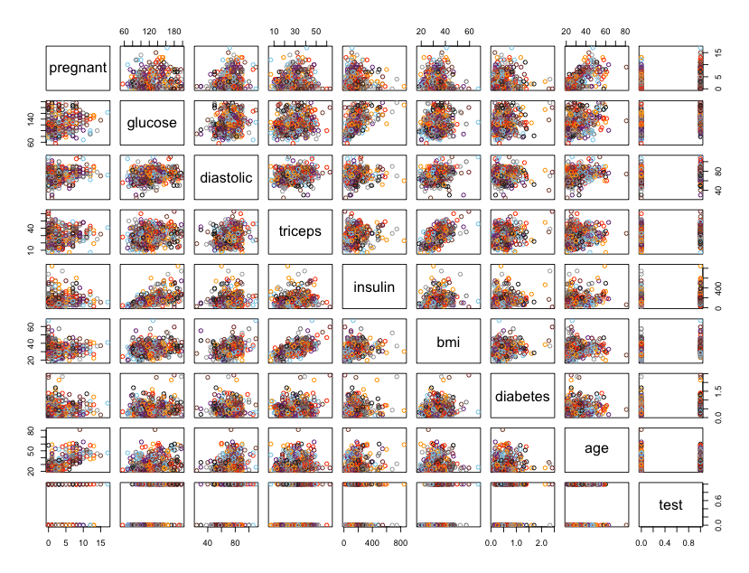

## Exercice 2

Dans les données, on charge les données de l’exercice à l’aide de la commande read.table et en y entrant l’URL des données.

### question 1

Pour faire la régression , on se place dans le script lié à la régression et on utiliser la commande lm pour régresser nos données.Ensuite , on stocke nos résultats dans un objet regr de type lm.  
On affiche les résultats :

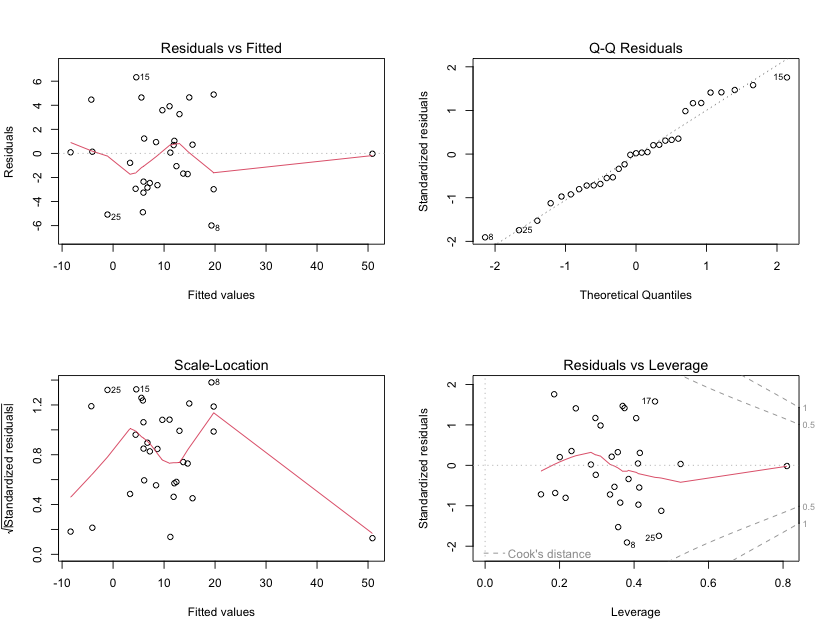

Afin d’évaluer la possible colinéarité entre les régresseurs, nous utiliserons la méthode de facteurs d’inflation de variance ( VIF ) à l’aide de la commande vif.

Les VIF mesurent l’augmentation de la variance des coefficients de régression dus à la corrélation des variables, sur une intervalle de $[1,+\infty[$. Si le vif est proche de$1$, ça indique une faible corrélation entre la variable et les régresseurs.

Pour s’y faire, on installe la librairie car et on applique vif à regr,  
et on l’affiche ( de manière plus esthétique à l’aide de la librairie knitr et kableExtra)

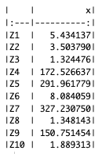

### question 2

Dans ce script , on utilise la commande step sur regr et on stock le résultat dans l’objet regr2.  
On voit une amélioration au niveau de la linéarité de la courbe de la première image quand on fait un plot :

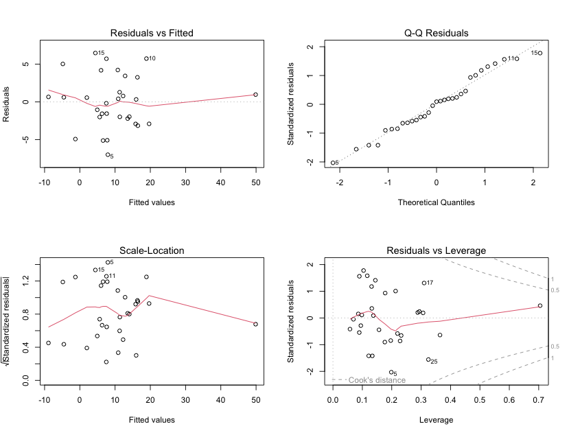